# Годовой заработок

Опрос US Bureau of Labor Statistics 2002 года содержит данные о годовом заработке 55729 участников; известны также их пол, возраст, уровень образования, тип работы.

Уровни образования: (1 = “no high school”, 2 = “some high school”, 3 = “high school diploma”, 4 = “some college”, 5 = “bachelor’s degree”, 6 = “postgraduate degree”)

Задание: оценить влияние образования, пола и типа работы на годовой заработок.

### 1. Подготовка данных

```r
library(gdata)
data <- read.xls("./workers.xls", )
data$SEX <- factor(data$SEX, labels = c("male", "female"))
data$JOB <- factor(data$JOB, labels = c("private-sector", "government", "self-employed"))
data$EDUC <- factor(data$EDUC)

workers = data[c("EARN", "SEX", "AGE", "EDUC", "JOB")]
save(workers,file="workers.Rda")
```

```r
library(DescTools)
library(clinfun)
library(agricolae)
library(multcomp)

load("./workers.Rda")
str(workers)
```

```
## 'data.frame':    55729 obs. of  5 variables:
##  $ EARN: int  7234 37413 29500 13500 17660 37250 20005 50602 10400 24960 ...
##  $ SEX : Factor w/ 2 levels "male","female": 2 1 2 2 1 1 2 2 1 2 ...
##  $ AGE : int  25 25 25 25 25 25 25 25 25 25 ...
##  $ EDUC: Factor w/ 6 levels "1","2","3","4",..: 2 5 4 3 4 4 4 5 3 5 ...
##  $ JOB : Factor w/ 3 levels "private-sector",..: 1 1 1 1 2 1 1 2 1 2 ...
```

```r
replications(EARN ~ EDUC + SEX + JOB, workers)
```

```
## $EDUC
## EDUC
##     1     2     3     4     5     6
##  2156  3668 17646 15703 10968  5588
##
## $SEX
## SEX
##   male female
##  29132  26597
##
## $JOB
## JOB
## private-sector     government  self-employed
##          40889           9429           5411
```

*Распределение годового дохода*

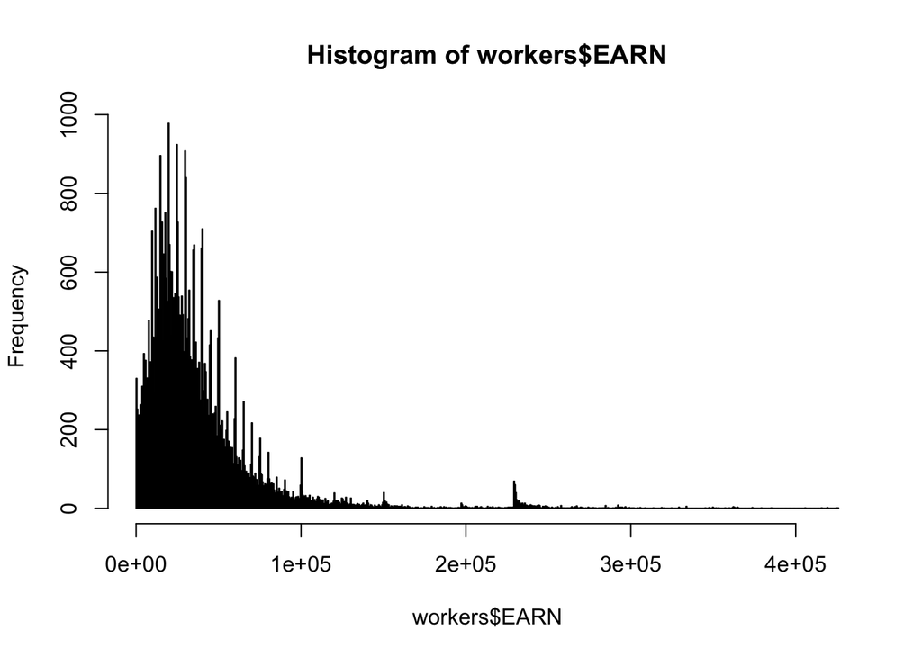

```r
hist(workers$EARN, nclass=1000)
```

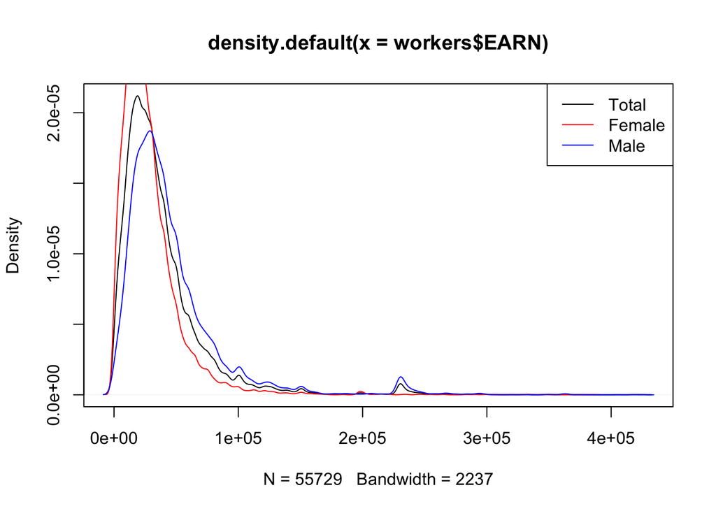

```r
plot(density(workers$EARN))
lines(density(workers$EARN[workers$SEX == "female"]), col="red")
lines(density(workers$EARN[workers$SEX == "male"]), col="blue")
legend("topright", c("Total", "Female", "Male"), lty=c(1,1), col=c("black", "red", "blue"))
```

**Из графика плотности годового дохода видно, что основная доля участников опроса находится до порога в 1e05. Кол-во участников, годовой доход которых выше порога - 2647. Их не будем учитывать в анализе. Итого в анализе участвует 53082 объекта.**

Далее будем исследовать только основную часть участников.

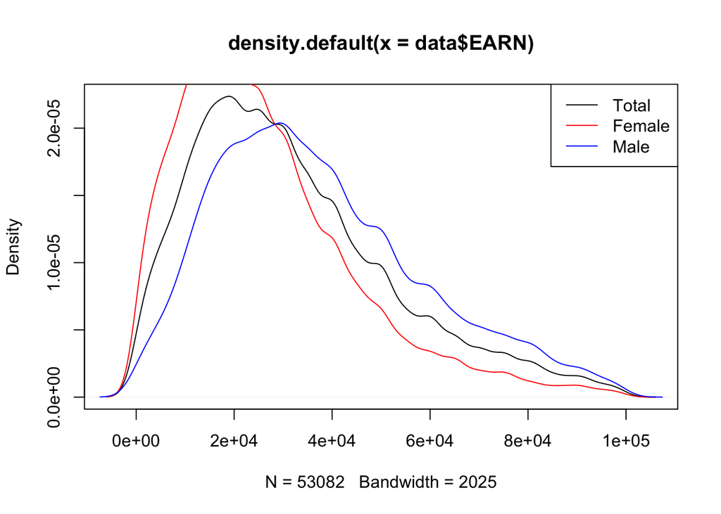

```r
target_samples = workers$EARN < 1e05
data <- workers[workers$EARN < 1e05,]
plot(density(data$EARN))
lines(density(data$EARN[data$SEX == "female"]), col="red")
lines(density(data$EARN[data$SEX == "male"]), col="blue")
legend("topright", c("Total", "Female", "Male"), lty=c(1,1), col=c("black", "red", "blue"))
```

### 2. Трёхфакторный дисперсионный анализ.

**(дизайн 2х6х3)**

```r
a1 <- aov(EARN ~ EDUC * SEX * JOB, data=data)
summary(a1)
```

```
##                 Df    Sum Sq   Mean Sq  F value   Pr(>F)
## EDUC             5 3.326e+12 6.653e+11 2079.700  < 2e-16 ***
## SEX              1 1.841e+12 1.841e+12 5755.970  < 2e-16 ***
## JOB              2 4.480e+10 2.240e+10   70.021  < 2e-16 ***
## EDUC:SEX         5 1.716e+10 3.432e+09   10.728 2.52e-10 ***
## EDUC:JOB        10 4.443e+10 4.443e+09   13.891  < 2e-16 ***
## SEX:JOB          2 2.454e+09 1.227e+09    3.836 0.021588 *
## EDUC:SEX:JOB    10 9.834e+09 9.834e+08    3.074 0.000648 ***
## Residuals    53046 1.697e+13 3.199e+08
## ---
## Signif. codes:  0 '***' 0.001 '**' 0.01 '*' 0.05 '.' 0.1 ' ' 1
```

Тройное взаимодействие значимо, разделим выборку по признаку SEX.

#### 2.1 Анализ участников мужского пола.

```r
maledata <- data[data$SEX == "male",]
```

```r
a1 <- aov(EARN ~ EDUC * JOB, data=maledata)
summary(a1)
```

```
##                Df    Sum Sq   Mean Sq  F value   Pr(>F)
## EDUC            5 1.991e+12 3.983e+11 1079.537  < 2e-16 ***
## JOB             2 1.747e+10 8.736e+09   23.681 5.30e-11 ***
## EDUC:JOB       10 2.756e+10 2.756e+09    7.471 5.66e-12 ***
## Residuals   26941 9.939e+12 3.689e+08
## ---
## Signif. codes:  0 '***' 0.001 '**' 0.01 '*' 0.05 '.' 0.1 ' ' 1
```

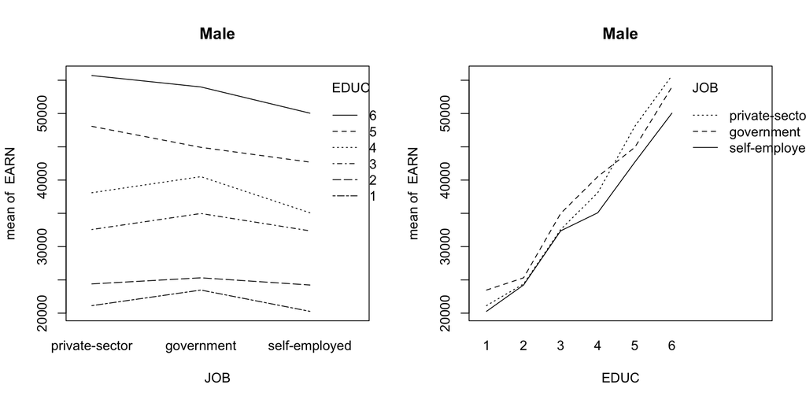

```r
par(mfrow=c(1,2))
with(maledata, interaction.plot(JOB, EDUC, EARN, main = "Male"))
with(maledata, interaction.plot(EDUC, JOB, EARN, main = "Male"))
```

Двойное взаимодействие образования(EDUC) и типа работы(JOB) значимо.

(1 = “no high school”, 2 = “some high school”, 3 = “high school diploma”, 4 = “some college”, 5 = “bachelor’s degree”, 6 = “postgraduate degree”)

**Сводка выводов из идущего далее анализа участников мужского пола**:

График справа:

- С ростом уровня образования растет годовой доход участника опроса, вне зависимости от типа работы. Гипотеза проверена с помощью критерия Джонкхие, p-value близки к нулю.
- Для типа работы private-sector, наименее значимая разница в размере дохода между уровнями образования 2-1 (3263(1252, 5275), p-value - 5.53e-05), все остальные пары уровней образования значимо различны (> 5529, p-value - 0)
- Для типа работы goverment, незначимая разница между 2-1 (1841(-6772, 10455), p-value - 0.99), все остальные пары уровней образования значимо различны.
- Для типа работы self-employed, незначимая разница между 2-1 (3959(-4379, 12298), p-value - 0.75) и 4-3 (2711(-402, 5825), p-value - 0.13), все остальные пары уровней образования значимо различны.

Разделим выборку по признаку JOB.

#### 2.1.1 Анализ каждого типа работы.

Анализируем годовой доход в зависимости от образования, для кажого типа работы.

```r
prmaledata <- maledata[maledata$JOB == "private-sector",]
gvmaledata <- maledata[maledata$JOB == "government",]
semaledata <- maledata[maledata$JOB == "self-employed",]
```

*Вывод*:

- С ростом уровня образования растет годовой доход участника, вне зависимости от типа работы. Гипотеза проверена с помощью критерия Джонкхие, p-value близки к нулю.

```r
# **Private-sector**
boxplot(EARN ~ EDUC, data=prmaledata)
jonckheere.test(prmaledata$EARN, as.numeric(prmaledata$EDUC), alternative = "increasing")

# **Government**
boxplot(EARN ~ EDUC, data=gvmaledata)
jonckheere.test(gvmaledata$EARN, as.numeric(gvmaledata$EDUC), alternative = "increasing")

# **self-employed**
boxplot(EARN ~ EDUC, data=semaledata)
jonckheere.test(semaledata$EARN, as.numeric(semaledata$EDUC), alternative = "increasing")
```

[output not shown]

*Для каждого типа работ, сравним попарно годовые доходы для всех уровней образования.*

```r
TukeyHSD(aov(EARN ~ EDUC, data=prmaledata), "EDUC", p.adj="holm")
TukeyHSD(aov(EARN ~ EDUC, data=gvmaledata), "EDUC", p.adj="holm")
TukeyHSD(aov(EARN ~ EDUC, data=semaledata), "EDUC", p.adj="holm")
```

[output not shown]

*Выводы*(на основе TukeyHSD с множественной поправкой holm):

- В Private-sector. Наименее значимая разница оказалась между 2-1 (3263(1252, 5275), p-value - 5.53e-05), все остальные пары уровней образования значимо различны (> 5529, p-value - 0)
- В Goverment. Незначимая разница между 2-1 (1841(-6772, 10455), p-value - 0.99), все остальные пары уровней образования значимо различны.
- В self-employed Незначимая разница между 2-1 (3959(-4379, 12298), p-value - 0.75) и 4-3 (2711(-402, 5825), p-value - 0.13), все остальные пары уровней образования значимо различны.

*Средний доход на каждом уровне образования, для каждого типа работы.*

```r
LSD.test(aov(EARN ~ EDUC, data=prmaledata), "EDUC", p.adj="holm")$means
```

```
##       EARN      std    r      LCL      UCL Min   Max
## 1 21132.58 12225.86 1185 20059.23 22205.92 300 94000
## 2 24396.48 14993.71 1793 23523.90 25269.07 150 98362
## 3 32570.65 17425.81 7117 32132.68 33008.63 200 99800
## 4 38099.73 19549.95 5382 37596.08 38603.38   5 99950
## 5 48076.98 22247.22 3465 47449.29 48704.68   5 99808
## 6 55712.95 23149.64 1205 54648.54 56777.35 110 99950
```

```r
LSD.test(aov(EARN ~ EDUC, data=gvmaledata), "EDUC", p.adj="holm")$means
```

```
##       EARN      std    r      LCL      UCL  Min   Max
## 1 23473.54 13702.24   52 18532.17 28414.91 5550 72053
## 2 25314.73 13835.27  119 22048.28 28581.18 3535 62037
## 3 34978.70 15883.87  911 33798.14 36159.27 1000 98000
## 4 40514.52 18193.48 1202 39486.75 41542.30 1800 99587
## 5 44918.72 18394.71  911 43738.15 46099.29  500 97769
## 6 53995.07 21107.62  752 52695.68 55294.46  850 99159
```

```r
LSD.test(aov(EARN ~ EDUC, data=semaledata), "EDUC", p.adj="holm")$means
```

```
##       EARN      std   r      LCL      UCL Min   Max
## 1 20273.66 17299.58  92 15622.51 24924.81   1 95960
## 2 24232.90 20187.78 177 20879.63 27586.16   1 99649
## 3 32372.86 21477.91 984 30950.67 33795.04   1 99002
## 4 35084.15 23278.15 777 33483.69 36684.60   1 98299
## 5 42699.57 23744.41 543 40785.08 44614.07   1 99999
## 6 50055.68 26314.18 292 47444.94 52666.41   1 99649
```

#### 2.1.2 Анализ каждого уровня образования.

```r
edu1maledata <- maledata[maledata$EDUC == "1",]
edu2maledata <- maledata[maledata$EDUC == "2",]
edu3maledata <- maledata[maledata$EDUC == "3",]
edu4maledata <- maledata[maledata$EDUC == "4",]
edu5maledata <- maledata[maledata$EDUC == "5",]
edu6maledata <- maledata[maledata$EDUC == "6",]
```

```r
TukeyHSD(aov(EARN ~ JOB, data=edu1maledata), "JOB", p.adj="holm")$JOB
```

```
##                                   diff       lwr      upr     p adj
## government-private-sector     2340.960 -1880.189 6562.109 0.3947157
## self-employed-private-sector  -858.915 -4083.316 2365.486 0.8064101
## self-employed-government     -3199.875 -8368.706 1968.956 0.3143668
```

```r
TukeyHSD(aov(EARN ~ JOB, data=edu3maledata), "JOB", p.adj="holm")$JOB
```

```
##                                    diff       lwr       upr        p adj
## government-private-sector     2408.0508   942.544 3873.5576 0.0003475002
## self-employed-private-sector  -197.7971 -1614.292 1218.6981 0.9426535361
## self-employed-government     -2605.8479 -4520.720 -690.9762 0.0040780960
```

- На уровне образования 2, доход во всех типах работ схож.

```r
TukeyHSD(aov(EARN ~ JOB, data=edu2maledata), "JOB", p.adj="holm")$JOB
```

```
##                                    diff       lwr      upr     p adj
## government-private-sector      918.2487 -2509.361 4345.859 0.8045644
## self-employed-private-sector  -163.5841 -3016.359 2689.190 0.9900779
## self-employed-government     -1081.8328 -5374.200 3210.534 0.8249043
```

- На уровне образования 5, 6, доход в private-sector > government > self-employed

```r
LSD.test(aov(EARN ~ JOB, data=edu5maledata), "JOB", p.adj="holm")$means
```

```
##                    EARN      std    r      LCL      UCL Min   Max
## government     44918.72 18394.71  911 43505.28 46332.16 500 97769
## private-sector 48076.98 22247.22 3465 47352.24 48801.73   5 99808
## self-employed  42699.57 23744.41  543 40868.79 44530.36   1 99999
```

```r
jonckheere.test(edu5maledata$EARN, as.numeric(edu5maledata$JOB), alternative = "decreasing")
```

```
##
##  Jonckheere-Terpstra test
##
## data:
## JT = 2502900, p-value = 5.47e-09
## alternative hypothesis: decreasing
```

```r
LSD.test(aov(EARN ~ JOB, data=edu6maledata), "JOB", p.adj="holm")$means
```

```
##                    EARN      std    r      LCL      UCL Min   Max
## government     53995.07 21107.62  752 52355.04 55635.11 850 99159
## private-sector 55712.95 23149.64 1205 54417.35 57008.54 110 99950
## self-employed  50055.68 26314.18  292 47423.77 52687.58   1 99649
```

```r
jonckheere.test(edu6maledata$EARN, as.numeric(edu6maledata$JOB), alternative = "decreasing")
```

```
##
##  Jonckheere-Terpstra test
##
## data:
## JT = 685320, p-value = 0.000405
## alternative hypothesis: decreasing
```

#### 2.2 Анализ участников женского пола.

```r
femaledata <- data[data$SEX == "female",]

a1 <- aov(EARN ~ EDUC * JOB, data=femaledata)
summary(a1)
```

```
##                Df    Sum Sq   Mean Sq  F value Pr(>F)
## EDUC            5 1.568e+12 3.135e+11 1164.349 <2e-16 ***
## JOB             2 3.044e+10 1.522e+10   56.513 <2e-16 ***
## EDUC:JOB       10 2.637e+10 2.637e+09    9.794 <2e-16 ***
## Residuals   26105 7.030e+12 2.693e+08
## ---
## Signif. codes:  0 '***' 0.001 '**' 0.01 '*' 0.05 '.' 0.1 ' ' 1
```

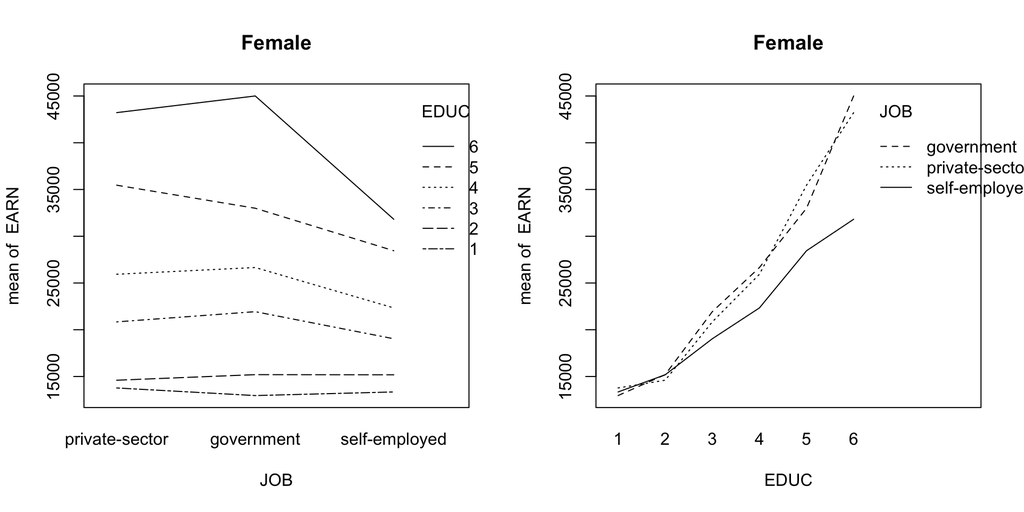

```r
par(mfrow=c(1,2))
with(femaledata, interaction.plot(JOB, EDUC, EARN, main = "Female"))
with(femaledata, interaction.plot(EDUC, JOB, EARN,main = "Female"))
```

Двойное взаимодействие значимо, разделим выборку по признаку JOB.

#### 2.2.1 Анализ типов работы участников женского пола.

**Private-sector**

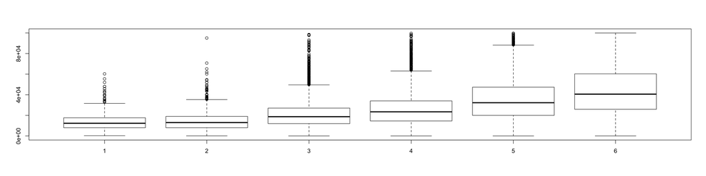

```r
prfemaledata <- femaledata[femaledata$JOB == "private-sector",]
boxplot(EARN ~ EDUC, data=prfemaledata)
```

```r
jonckheere.test(prfemaledata$EARN, as.numeric(prfemaledata$EDUC), alternative = "increasing")
```

```
##
##  Jonckheere-Terpstra test
##
## data:
## JT = 89913000, p-value < 2.2e-16
## alternative hypothesis: increasing
```

Уровень годового дохада растет в зависимости от образования.

**Government**

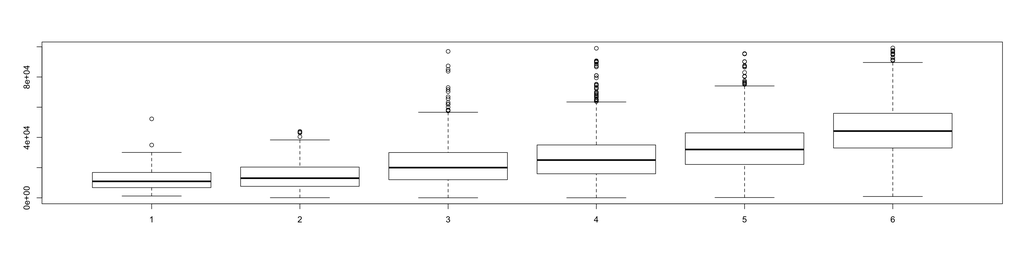

```r
gvfemaledata <- femaledata[femaledata$JOB == "government",]
boxplot(EARN ~ EDUC, data=gvfemaledata)
```

```r
jonckheere.test(gvfemaledata$EARN, as.numeric(gvfemaledata$EDUC), alternative = "increasing")
```

```
##
##  Jonckheere-Terpstra test
##
## data:
## JT = 7507900, p-value < 2.2e-16
## alternative hypothesis: increasing
```

**self-employed**

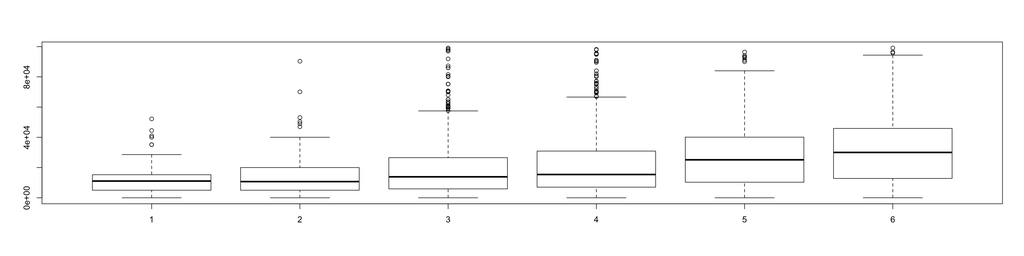

```r
sefemaledata <- femaledata[femaledata$JOB == "self-employed",]
boxplot(EARN ~ EDUC, data=sefemaledata)
```

```r
jonckheere.test(sefemaledata$EARN, as.numeric(sefemaledata$EDUC), alternative = "increasing")
```

```
##
##  Jonckheere-Terpstra test
##
## data:
## JT = 797640, p-value < 2.2e-16
## alternative hypothesis: increasing
```

Сравним годовой доход

```r
a1 <- aov(EARN ~ EDUC, data=sefemaledata)
LSD2 <- LSD.test(a1, "EDUC", p.adj="bonferroni",console=TRUE)
```

```
##
## Study: a1 ~ "EDUC"
##
## LSD t Test for EARN
## P value adjustment method: bonferroni
##
## Mean Square Error:  400731736
##
## EDUC,  means and individual ( 95 %) CI
##
##       EARN      std   r       LCL      UCL Min   Max
## 1 13346.52 12390.98  48  7679.761 19013.28   1 52201
## 2 15182.56 15931.63  93 11111.439 19253.68   1 90337
## 3 19035.78 18258.77 605 17439.619 20631.95   1 99066
## 4 22334.79 20552.57 577 20700.351 23969.22   1 98169
## 5 28449.36 22077.26 393 26468.936 30429.79   1 96400
## 6 31814.27 22775.62 165 28757.850 34870.70  20 99100
##
## alpha: 0.05 ; Df Error: 1875
## Critical Value of t: 2.938967
##
## Minimum difference changes for each comparison
##
## Means with the same letter are not significantly different.
##
## Groups, Treatments and means
## a     6   31810
## a     5   28450
## b     4   22330
## bc    3   19040
## c     2   15180
## c     1   13350
```

```r
TukeyHSD(a1, "EDUC", p.adj="bonferroni")
```

```
##   Tukey multiple comparisons of means
##     95% family-wise confidence level
##
## Fit: aov(formula = EARN ~ EDUC, data = sefemaledata)
##
## $EDUC
##          diff         lwr       upr     p adj
## 2-1  1836.038 -8312.98966 11985.066 0.9955662
## 3-1  5689.263 -2873.92125 14252.447 0.4053072
## 4-1  8988.264   409.82128 17566.707 0.0337119
## 5-1 15102.843  6371.53346 23834.153 0.0000130
## 6-1 18467.752  9102.82920 27832.675 0.0000003
## 3-2  3853.224 -2507.19188 10213.641 0.5131602
## 4-2  7152.226   771.28088 13533.171 0.0176661
## 5-2 13266.805  6681.78059 19851.829 0.0000002
## 6-2 16631.714  9227.08307 24036.344 0.0000000
## 4-3  3299.002   -23.92025  6621.923 0.0529553
## 5-3  9413.580  5713.86520 13113.296 0.0000000
## 6-3 12778.489  7763.12259 17793.856 0.0000000
## 5-4  6114.579  2379.68141  9849.476 0.0000473
## 6-4  9479.488  4438.11198 14520.863 0.0000014
## 6-5  3364.909 -1932.40662  8662.224 0.4581244
```

```r
model.tables(a1, "means")$tables$EDUC
```

```
## EDUC
##        1        2        3        4        5        6
## 13346.52 15182.56 19035.78 22334.79 28449.36 31814.27
```

Вывод: Участники женского пола с образованием

- “no high school”, “some high school” - 13-15к
- “high school diploma”, “some college” - 19-22к
- “bachelor’s degree”, “postgraduate degree” - 28-31к

#### 2.2.2 Анализ образования участников женского пола.

**1 no high school**

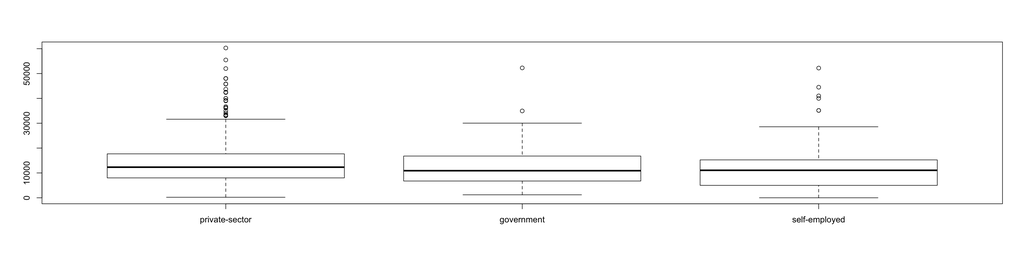

```r
edu1femaledata <- femaledata[femaledata$EDUC == "1",]
boxplot(EARN ~ JOB, data=edu1femaledata)
```

```r
a1 <- aov(EARN ~ JOB, data=edu1femaledata)
TukeyHSD(a1, "JOB", p.adj="bonferroni")
```

```
##   Tukey multiple comparisons of means
##     95% family-wise confidence level
##
## Fit: aov(formula = EARN ~ JOB, data = edu1femaledata)
##
## $JOB
##                                   diff       lwr      upr     p adj
## government-private-sector    -813.5536 -3764.107 2137.000 0.7938852
## self-employed-private-sector -426.9366 -3489.973 2636.099 0.9426749
## self-employed-government      386.6170 -3725.631 4498.865 0.9734947
```

```r
model.tables(a1, "means")$tables$JOB
```

```
## JOB
## private-sector     government  self-employed
##       13773.46       12959.90       13346.52
```

**2 some high school**

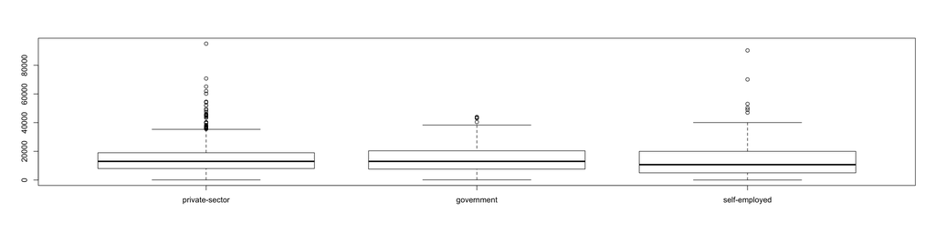

```r
edu2femaledata <- femaledata[femaledata$EDUC == "2",]
boxplot(EARN ~ JOB, data=edu2femaledata)
```

```r
a1 <- aov(EARN ~ JOB, data=edu2femaledata)
TukeyHSD(a1, "JOB", p.adj="bonferroni")
```

```
##   Tukey multiple comparisons of means
##     95% family-wise confidence level
##
## Fit: aov(formula = EARN ~ JOB, data = edu2femaledata)
##
## $JOB
##                                  diff       lwr      upr     p adj
## government-private-sector    596.3265 -1510.864 2703.517 0.7844768
## self-employed-private-sector 581.3750 -1970.403 3133.153 0.8543732
## self-employed-government     -14.9515 -3192.639 3162.736 0.9999328
```

```r
model.tables(a1, "means")$tables$JOB
```

```
## JOB
## private-sector     government  self-employed
##       14601.18       15197.51       15182.56
```

**3 high school diploma**

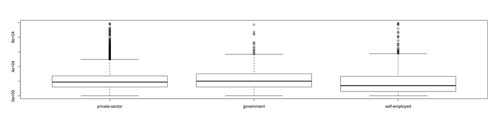

```r
edu3femaledata <- femaledata[femaledata$EDUC == "3",]
boxplot(EARN ~ JOB, data=edu3femaledata)
```

```r
a1 <- aov(EARN ~ JOB, data=edu3femaledata)
TukeyHSD(a1, "JOB", p.adj="bonferroni")
```

```
##   Tukey multiple comparisons of means
##     95% family-wise confidence level
##
## Fit: aov(formula = EARN ~ JOB, data = edu3femaledata)
##
## $JOB
##                                   diff        lwr        upr     p adj
## government-private-sector     1092.993   102.2982  2083.6887 0.0262983
## self-employed-private-sector -1803.782 -3167.6899  -439.8747 0.0055095
## self-employed-government     -2896.776 -4486.5261 -1307.0254 0.0000583
```

```r
model.tables(a1, "means")$tables$JOB
```

```
## JOB
## private-sector     government  self-employed
##       20839.57       21932.56       19035.78
```

**4 some college**

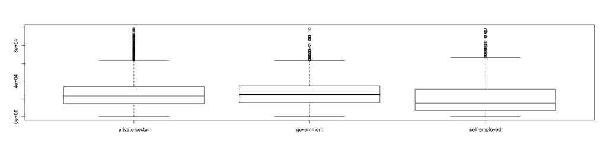

```r
edu4femaledata <- femaledata[femaledata$EDUC == "4",]
boxplot(EARN ~ JOB, data=edu4femaledata)
```

```r
a1 <- aov(EARN ~ JOB, data=edu4femaledata)
TukeyHSD(a1, "JOB", p.adj="bonferroni")
```

```
##   Tukey multiple comparisons of means
##     95% family-wise confidence level
##
## Fit: aov(formula = EARN ~ JOB, data = edu4femaledata)
##
## $JOB
##                                    diff        lwr       upr     p adj
## government-private-sector      721.3612  -442.8076  1885.530 0.3141213
## self-employed-private-sector -3599.2304 -5289.8120 -1908.649 0.0000018
## self-employed-government     -4320.5916 -6247.2351 -2393.948 0.0000005
```

```r
model.tables(a1, "means")$tables$JOB
```

```
## JOB
## private-sector     government  self-employed
##       25934.01       26655.38       22334.78
```

**5 bachelor’s degree**

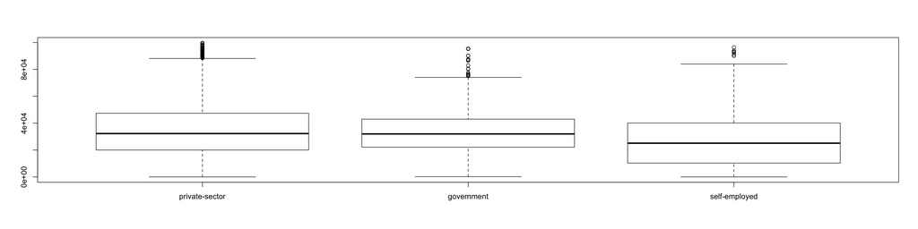

```r
edu5femaledata <- femaledata[femaledata$EDUC == "5",]
boxplot(EARN ~ JOB, data=edu5femaledata)
```

```r
a1 <- aov(EARN ~ JOB, data=edu5femaledata)
TukeyHSD(a1, "JOB", p.adj="bonferroni")
```

```
##   Tukey multiple comparisons of means
##     95% family-wise confidence level
##
## Fit: aov(formula = EARN ~ JOB, data = edu5femaledata)
##
## $JOB
##                                   diff       lwr       upr     p adj
## government-private-sector    -2463.643 -3975.533  -951.753 0.0003965
## self-employed-private-sector -7009.206 -9524.820 -4493.592 0.0000000
## self-employed-government     -4545.563 -7245.205 -1845.922 0.0002362
```

```r
model.tables(a1, "means")$tables$JOB
```

```
## JOB
## private-sector     government  self-employed
##       35458.57       32994.93       28449.36
```

**postgraduate degree**

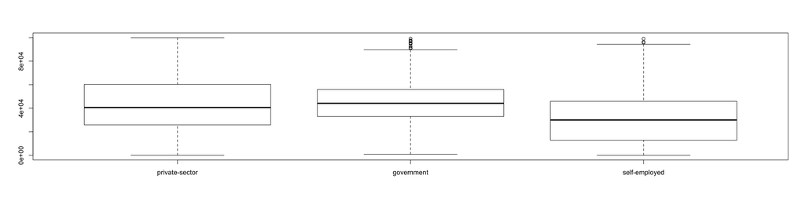

```r
edu6femaledata <- femaledata[femaledata$EDUC == "6",]
boxplot(EARN ~ JOB, data=edu6femaledata)
```

```r
a1 <- aov(EARN ~ JOB, data=edu6femaledata)
TukeyHSD(a1, "JOB", p.adj="bonferroni")
```

```
##   Tukey multiple comparisons of means
##     95% family-wise confidence level
##
## Fit: aov(formula = EARN ~ JOB, data = edu6femaledata)
##
## $JOB
##                                   diff         lwr       upr     p adj
## government-private-sector      1782.72   -343.3213  3908.760 0.1208041
## self-employed-private-sector -11406.56 -15501.4700 -7311.644 0.0000000
## self-employed-government     -13189.28 -17266.3641 -9112.189 0.0000000
```

```r
model.tables(a1, "means")$tables$JOB
```

```
## JOB
## private-sector     government  self-employed
##       43220.83       45003.55       31814.27
```

Женский пол:

- В группах “no high school” “some high school” отклонение дохода находится в интервале -1000, 1000. Годовой уровень - 14к.
- В группе “high school diploma” 20к +-1к
- В группе “some college” средний доход - 24к,(+-3к)
- В группе “bachelor’s degree” большой разброс, минимальный доход у женщин в self-emloyed(28к), максимальный в private-sector(35к), government(32к)
- В группе “postgraduate degree” большой разброс, минимальный доход у женщин в self-emloyed(31к), максимальный в government(45к), private-sector(43к)

#### 3 Выводы

SEX:

EDUC:

- Чем выше уровень образования участника, тем выше его годовой доход, вне зависимости от пола и типа работы.
- “no high school” “some high school” можно объеденить в одну группу.